# Predictive Modeling with Linear Regression Project: ReCell

## Problem Statement

### Business Context

Buying and selling used phones and tablets used to be something that happened on a handful of online marketplace sites. But the used and refurbished device market has grown considerably over the past decade, and a new IDC (International Data Corporation) forecast predicts that the used phone market would be worth $52.7bn by 2023 with a compound annual growth rate (CAGR) of 13.6% from 2018 to 2023. This growth can be attributed to an uptick in demand for used phones and tablets that offer considerable savings compared with new models.

Refurbished and used devices continue to provide cost-effective alternatives to both consumers and businesses that are looking to save money when purchasing one. There are plenty of other benefits associated with the used device market. Used and refurbished devices can be sold with warranties and can also be insured with proof of purchase. Third-party vendors/platforms, such as Verizon, Amazon, etc., provide attractive offers to customers for refurbished devices. Maximizing the longevity of devices through second-hand trade also reduces their environmental impact and helps in recycling and reducing waste. The impact of the COVID-19 outbreak may further boost this segment as consumers cut back on discretionary spending and buy phones and tablets only for immediate needs.

### Objective

The rising potential of this comparatively under-the-radar market fuels the need for an ML-based solution to develop a dynamic pricing strategy for used and refurbished devices. ReCell, a startup aiming to tap the potential in this market, has hired you as a data scientist. They want you to analyze the data provided and build a linear regression model to predict the price of a used phone/tablet and identify factors that significantly influence it.

### Data Description

The data contains the different attributes of used/refurbished phones and tablets. The data was collected in the year 2021. The detailed data dictionary is given below.

- brand_name: Name of manufacturing brand
- os: OS on which the device runs
- screen_size: Size of the screen in cm
- 4g: Whether 4G is available or not
- 5g: Whether 5G is available or not
- main_camera_mp: Resolution of the rear camera in megapixels
- selfie_camera_mp: Resolution of the front camera in megapixels
- int_memory: Amount of internal memory (ROM) in GB
- ram: Amount of RAM in GB
- battery: Energy capacity of the device battery in mAh
- weight: Weight of the device in grams
- release_year: Year when the device model was released
- days_used: Number of days the used/refurbished device has been used
- normalized_new_price: Normalized price of a new device of the same model in euros
- normalized_used_price: Normalized price of the used/refurbished device in euros

## Importing necessary libraries

```python
# Installing the libraries with the specified version.
# uncomment and run the following line if Google Colab is being used
!pip install scikit-learn==1.2.2 seaborn==0.13.1 matplotlib==3.7.1 numpy==1.25.2 pandas==1.5.3 -q --user
```

[output not shown]

```python
# Installing the libraries with the specified version.
# uncomment and run the following lines if Jupyter Notebook is being used
!pip install scikit-learn==1.2.2 seaborn==0.11.1 matplotlib==3.3.4 numpy==1.24.3 pandas==1.5.2 -q --user
```

[output not shown]

**Note**: *After running the above cell, kindly restart the notebook kernel and run all cells sequentially from the start again.*

```python
# Libraries to help with reading and manipulating data
import numpy as np
import pandas as pd
```

## Loading the dataset

```python
# uncomment and run the below code snippets if the dataset is present in the Google Drive
from google.colab import drive
drive.mount('/content/drive')
```

```python
# loading data
data = pd.read_csv('/content/drive/MyDrive/Colab Notebooks/used_device_data.csv') ## Complete the code to read the data
```

## Data Overview

- Observations
- Sanity checks

```python
# Write your code here to view the first 5 rows
#Load data from .CSV file and print first 5 rows.
#Observation

df = pd.read_csv("/content/drive/MyDrive/Colab Notebooks/used_device_data.csv")
pd.set_option('display.expand_frame_repr', False)

# View the first 5 rows of the dataset
print("First 5 rows of the data:")
display(df.head())

# View the last 5 rows of the dataset
print("\nLast 5 rows of the data:")
display(df.tail())

# Check the shape of the dataset (Rows, Columns)
print(f"\nThe dataset has {df.shape[0]} rows and {df.shape[1]} columns.")

# Check data types and non-null counts
print("\nData Information:")
df.info()
```

```
First 5 rows of the data:
```

|  | brand_name | os | screen_size | 4g | 5g | main_camera_mp | selfie_camera_mp | int_memory | ram | battery | weight | release_year | days_used | normalized_used_price | normalized_new_price |
| --- | --- | --- | --- | --- | --- | --- | --- | --- | --- | --- | --- | --- | --- | --- | --- |
| 0 | Honor | Android | 14.50 | yes | no | 13.0 | 5.0 | 64.0 | 3.0 | 3020.0 | 146.0 | 2020 | 127 | 4.307572 | 4.715100 |
| 1 | Honor | Android | 17.30 | yes | yes | 13.0 | 16.0 | 128.0 | 8.0 | 4300.0 | 213.0 | 2020 | 325 | 5.162097 | 5.519018 |
| 2 | Honor | Android | 16.69 | yes | yes | 13.0 | 8.0 | 128.0 | 8.0 | 4200.0 | 213.0 | 2020 | 162 | 5.111084 | 5.884631 |
| 3 | Honor | Android | 25.50 | yes | yes | 13.0 | 8.0 | 64.0 | 6.0 | 7250.0 | 480.0 | 2020 | 345 | 5.135387 | 5.630961 |
| 4 | Honor | Android | 15.32 | yes | no | 13.0 | 8.0 | 64.0 | 3.0 | 5000.0 | 185.0 | 2020 | 293 | 4.389995 | 4.947837 |

```
Last 5 rows of the data:
```

|  | brand_name | os | screen_size | 4g | 5g | main_camera_mp | selfie_camera_mp | int_memory | ram | battery | weight | release_year | days_used | normalized_used_price | normalized_new_price |
| --- | --- | --- | --- | --- | --- | --- | --- | --- | --- | --- | --- | --- | --- | --- | --- |
| 3449 | Asus | Android | 15.34 | yes | no | NaN | 8.0 | 64.0 | 6.0 | 5000.0 | 190.0 | 2019 | 232 | 4.492337 | 6.483872 |
| 3450 | Asus | Android | 15.24 | yes | no | 13.0 | 8.0 | 128.0 | 8.0 | 4000.0 | 200.0 | 2018 | 541 | 5.037732 | 6.251538 |
| 3451 | Alcatel | Android | 15.80 | yes | no | 13.0 | 5.0 | 32.0 | 3.0 | 4000.0 | 165.0 | 2020 | 201 | 4.357350 | 4.528829 |
| 3452 | Alcatel | Android | 15.80 | yes | no | 13.0 | 5.0 | 32.0 | 2.0 | 4000.0 | 160.0 | 2020 | 149 | 4.349762 | 4.624188 |
| 3453 | Alcatel | Android | 12.83 | yes | no | 13.0 | 5.0 | 16.0 | 2.0 | 4000.0 | 168.0 | 2020 | 176 | 4.132122 | 4.279994 |

```
The dataset has 3454 rows and 15 columns.

Data Information:
<class 'pandas.core.frame.DataFrame'>
RangeIndex: 3454 entries, 0 to 3453
Data columns (total 15 columns):
 #   Column                 Non-Null Count  Dtype
---  ------                 --------------  -----
 0   brand_name             3454 non-null   object
 1   os                     3454 non-null   object
 2   screen_size            3454 non-null   float64
 3   4g                     3454 non-null   object
 4   5g                     3454 non-null   object
 5   main_camera_mp         3275 non-null   float64
 6   selfie_camera_mp       3452 non-null   float64
 7   int_memory             3450 non-null   float64
 8   ram                    3450 non-null   float64
 9   battery                3448 non-null   float64
 10  weight                 3447 non-null   float64
 11  release_year           3454 non-null   int64
 12  days_used              3454 non-null   int64
 13  normalized_used_price  3454 non-null   float64
 14  normalized_new_price   3454 non-null   float64
dtypes: float64(9), int64(2), object(4)
memory usage: 404.9+ KB
```

```python
#Sanity Checks
# 1. Check for missing values
print("Missing values in each column:")
print(df.isnull().sum())

# 2. Check for duplicate rows
print(f"\nNumber of duplicate rows: {df.duplicated().sum()}")

# 3. Statistical summary (Sanity check for outliers/logical ranges)
# This will show if 'days_used' or 'ram' have impossible negative values
print("\nStatistical summary of numerical columns:")
display(df.describe().T)

# 4. Check unique values for categorical columns (brand_name, os, 4g, 5g)
# This helps identify typos or inconsistent naming
categorical_cols = ['brand_name', 'os', '4g', '5g', 'release_year']
print("\nUnique values in categorical columns:")
for col in categorical_cols:
    print(f"{col}: {df[col].nunique()} unique values")
```

```
Missing values in each column:
brand_name                 0
os                         0
screen_size                0
4g                         0
5g                         0
main_camera_mp           179
selfie_camera_mp           2
int_memory                 4
ram                        4
battery                    6
weight                     7
release_year               0
days_used                  0
normalized_used_price      0
normalized_new_price       0
dtype: int64

Number of duplicate rows: 0

Statistical summary of numerical columns:
```

|  | count | mean | std | min | 25% | 50% | 75% | max |
| --- | --- | --- | --- | --- | --- | --- | --- | --- |
| screen_size | 3454.0 | 13.713115 | 3.805280 | 5.080000 | 12.700000 | 12.830000 | 15.340000 | 30.710000 |
| main_camera_mp | 3275.0 | 9.460208 | 4.815461 | 0.080000 | 5.000000 | 8.000000 | 13.000000 | 48.000000 |
| selfie_camera_mp | 3452.0 | 6.554229 | 6.970372 | 0.000000 | 2.000000 | 5.000000 | 8.000000 | 32.000000 |
| int_memory | 3450.0 | 54.573099 | 84.972371 | 0.010000 | 16.000000 | 32.000000 | 64.000000 | 1024.000000 |
| ram | 3450.0 | 4.036122 | 1.365105 | 0.020000 | 4.000000 | 4.000000 | 4.000000 | 12.000000 |
| battery | 3448.0 | 3133.402697 | 1299.682844 | 500.000000 | 2100.000000 | 3000.000000 | 4000.000000 | 9720.000000 |
| weight | 3447.0 | 182.751871 | 88.413228 | 69.000000 | 142.000000 | 160.000000 | 185.000000 | 855.000000 |
| release_year | 3454.0 | 2015.965258 | 2.298455 | 2013.000000 | 2014.000000 | 2015.500000 | 2018.000000 | 2020.000000 |
| days_used | 3454.0 | 674.869716 | 248.580166 | 91.000000 | 533.500000 | 690.500000 | 868.750000 | 1094.000000 |
| normalized_used_price | 3454.0 | 4.364712 | 0.588914 | 1.536867 | 4.033931 | 4.405133 | 4.755700 | 6.619433 |
| normalized_new_price | 3454.0 | 5.233107 | 0.683637 | 2.901422 | 4.790342 | 5.245892 | 5.673718 | 7.847841 |

```
Unique values in categorical columns:
brand_name: 34 unique values
os: 4 unique values
4g: 2 unique values
5g: 2 unique values
release_year: 8 unique values
```

## Exploratory Data Analysis (EDA)

- EDA is an important part of any project involving data.
- It is important to investigate and understand the data better before building a model with it.
- A few questions have been mentioned below which will help you approach the analysis in the right manner and generate insights from the data.
- A thorough analysis of the data, in addition to the questions mentioned below, should be done.

**Questions**:

1. What does the distribution of normalized used device prices look like?
2. What percentage of the used device market is dominated by Android devices?
3. The amount of RAM is important for the smooth functioning of a device. How does the amount of RAM vary with the brand?
4. A large battery often increases a device's weight, making it feel uncomfortable in the hands. How does the weight vary for phones and tablets offering large batteries (more than 4500 mAh)?
5. Bigger screens are desirable for entertainment purposes as they offer a better viewing experience. How many phones and tablets are available across different brands with a screen size larger than 6 inches?
6. A lot of devices nowadays offer great selfie cameras, allowing us to capture our favorite moments with loved ones. What is the distribution of devices offering greater than 8MP selfie cameras across brands?
7. Which attributes are highly correlated with the normalized price of a used device?
1. Distribution of Normalized Used Device Prices. This helps visualize the spread and skewness of your target variable.

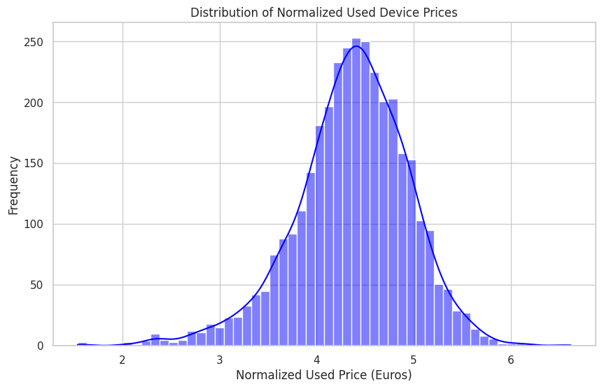

```python
import matplotlib.pyplot as plt
import seaborn as sns

plt.figure(figsize=(10, 6))
sns.histplot(df['normalized_used_price'], kde=True, color='blue')
plt.title('Distribution of Normalized Used Device Prices')
plt.xlabel('Normalized Used Price (Euros)')
plt.ylabel('Frequency')
plt.show()
```

Observation:

Shape of Distribution: The variable normalized_used_price follows a near-normal distribution.

Skewness: The distribution exhibits a slight left skew, as evidenced by the longer tail extending toward the lower price values on the left side of the horizontal axis.

Central Tendency: The peak frequency (mode) of the distribution is centered at approximately 4.5 on the normalized scale.

Data Range: Most of the data points for used device prices fall between the values of 3.0 and 5.5.

Outliers: There appear to be a few extreme low-value observations below 2.0, indicating the presence of some lower-priced outliers in the dataset.distributed.

2. Percentage of Android Devices in the Market. We filter the os column to find the proportion of Android users.

```
Percentage of used device market dominated by Android: 93.05%
```

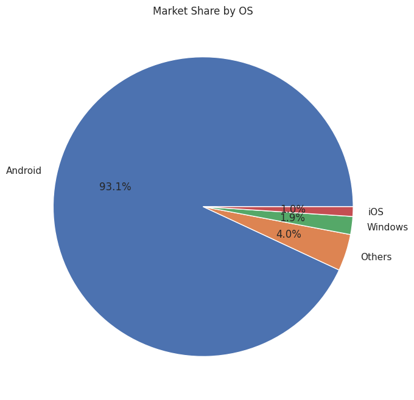

```python
# Calculate percentage
android_count = df[df['os'] == 'Android'].shape[0]
total_devices = df.shape[0]
android_pct = (android_count / total_devices) * 100

print(f"Percentage of used device market dominated by Android: {android_pct:.2f}%")

# Optional: Visualization
df['os'].value_counts(normalize=True).plot(kind='pie', autopct='%1.1f%%', figsize=(8,8))
plt.title('Market Share by OS')
plt.ylabel('')
plt.show()
```

Observation: the Android operating system dominates 93.05% of the used device market.

3. Variation of RAM with Brand This boxplot reveals how different brands prioritize memory capacity.

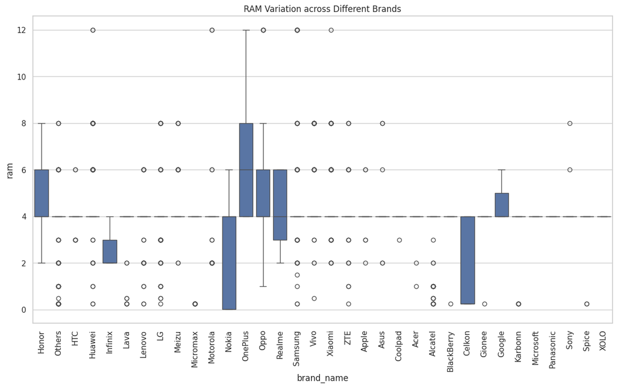

```python
plt.figure(figsize=(15, 8))
sns.boxplot(data=df, x='brand_name', y='ram')
plt.xticks(rotation=90)
plt.title('RAM Variation across Different Brands')
plt.show()
```

Observation: the amount of RAM varies significantly across different smartphone brands, reflecting different market strategies and hardware priorities:

High-Performance Leaders: OnePlus shows the highest median RAM, centered at approximately 6 GB, with a distribution that reaches up to 12 GB.

Mid-to-High Range Focus: Brands like Honor, Oppo, and Realme also prioritize higher memory, with medians typically situated between 4 GB and 6 GB.

Broad Market Presence: Major brands such as Samsung, Xiaomi, and Vivo maintain a median RAM of 4 GB, but they exhibit numerous outliers reaching 8 GB and 12 GB, indicating a wide product range from entry-level to flagship devices.

Specialized Stability: Google displays a very tight distribution around the 4 GB to 5 GB mark, showing less variation in RAM across its device lineup compared to other manufacturers.

4. Weight Variation for Large Battery Devices (>4500 mAh). This scatter plot helps identify the relationship between energy capacity and device weight.

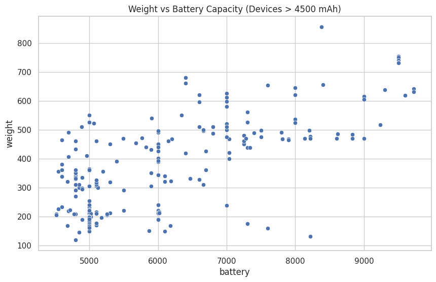

```python
# Filtering for devices with large batteries
large_battery_df = df[df['battery'] > 4500]

plt.figure(figsize=(10, 6))
sns.scatterplot(data=large_battery_df, x='battery', y='weight')
plt.title('Weight vs Battery Capacity (Devices > 4500 mAh)')
plt.show()
```

Observation:

Positive Correlation: There is a generally positive trend between battery capacity and device weight; as the battery capacity increases from 4500 mAh toward 10,000 mAh, the weight of the devices tends to rise.

5. Brands with Screens Larger Than 6 Inches Note: The data dictionary lists screen size in cm. Since 6 inches $\approx$ 15.24 cm, we ensure we use the correct unit conversion.

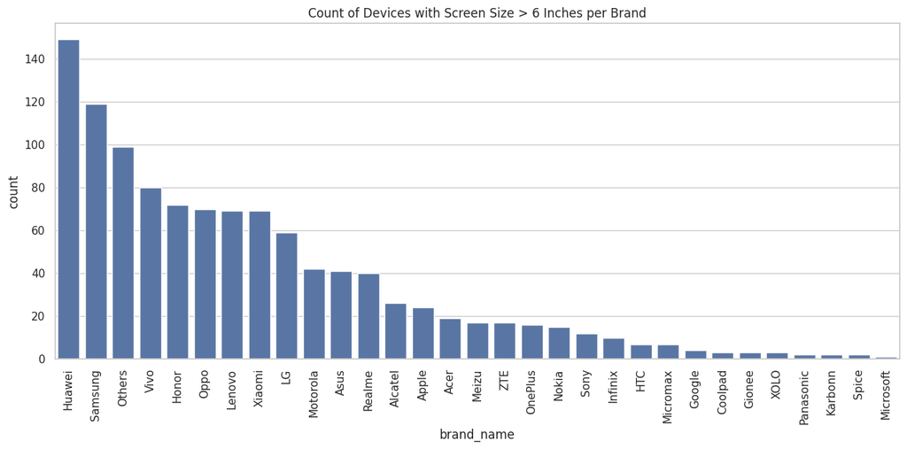

```python
# Converting 6 inches to cm for the screen_size column
six_inches_cm = 15.24
large_screens = df[df['screen_size'] > six_inches_cm]

plt.figure(figsize=(15, 6))
sns.countplot(data=large_screens, x='brand_name', order=large_screens['brand_name'].value_counts().index)
plt.xticks(rotation=90)
plt.title('Count of Devices with Screen Size > 6 Inches per Brand')
plt.show()
```

Observation: Large Screen Availability ( > 6 Inches / 15.24 cm) The bar chart indicates that there is a significant inventory of devices with screens larger than 6 inches across numerous brands. This is a crucial metric for a pricing strategy, as larger screens generally command higher premiums in the used market.

6. Distribution of Devices with >8MP Selfie Cameras High-quality front cameras are a significant selling point in the modern market.

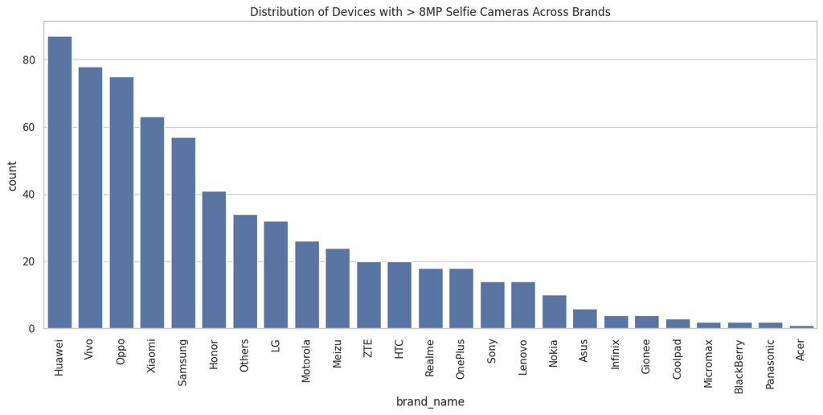

```python
high_selfie_df = df[df['selfie_camera_mp'] > 8]

plt.figure(figsize=(15, 6))
sns.countplot(data=high_selfie_df, x='brand_name', order=high_selfie_df['brand_name'].value_counts().index)
plt.xticks(rotation=90)
plt.title('Distribution of Devices with > 8MP Selfie Cameras Across Brands')
plt.show()
```

Observation: The high volume of devices from brands like Huawei, Vivo, and Oppo in the > 8MP category suggests that "Selfie Camera Resolution" is a competitive feature. In predictive model, selfie_camera_mp is likely to be a significant coefficient, as modern consumers often equate higher megapixels with better device value, especially for social-media-focused demographics.

7. Correlation with Normalized Used Price A heatmap is the most effective way to identify which features (like ram, battery, or release_year) influence the price.

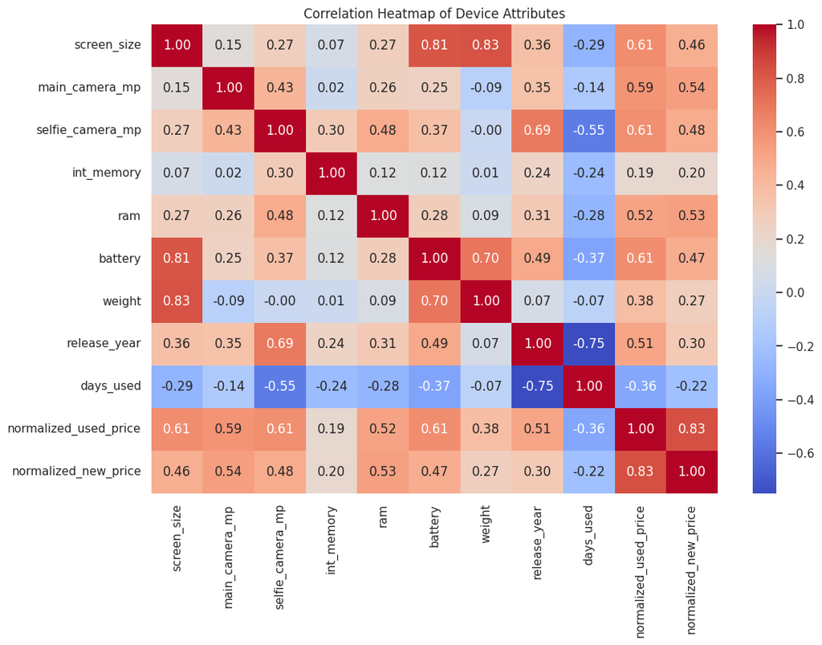

```
Correlation of attributes with Normalized Used Price:
normalized_used_price    1.000000
normalized_new_price     0.834496
screen_size              0.614785
battery                  0.613619
selfie_camera_mp         0.608074
main_camera_mp           0.587302
ram                      0.520289
release_year             0.509790
weight                   0.382354
int_memory               0.190993
days_used               -0.358264
Name: normalized_used_price, dtype: float64
```

```python
plt.figure(figsize=(12, 8))
# Calculate correlation only for numeric columns
correlation_matrix = df.select_dtypes(include=['float64', 'int64']).corr()
sns.heatmap(correlation_matrix, annot=True, cmap='coolwarm', fmt=".2f")
plt.title('Correlation Heatmap of Device Attributes')
plt.show()

# Highlighting factors for used price specifically
print("Correlation of attributes with Normalized Used Price:")
print(correlation_matrix['normalized_used_price'].sort_values(ascending=False))
```

Observation on Multicollinearity: Looking at the heatmap, we notice that screen_size, battery, and weight are all highly correlated with each other ($r \ge 0.70$).

## Data Preprocessing

- Missing value treatment
- Feature engineering (if needed)
- Outlier detection and treatment (if needed)
- Preparing data for modeling
- Any other preprocessing steps (if needed)

```python
#Missing value treatment:
# Check for missing values
print(df.isnull().sum())

# Strategy: Fill numerical missing values with the median (robust to outliers)
# and categorical values with the mode.
num_cols = df.select_dtypes(include=['float64', 'int64']).columns
for col in num_cols:
    df[col] = df[col].fillna(df[col].median())

cat_cols = df.select_dtypes(include=['object']).columns
for col in cat_cols:
    df[col] = df[col].fillna(df[col].mode()[0])
```

```
brand_name                 0
os                         0
screen_size                0
4g                         0
5g                         0
main_camera_mp           179
selfie_camera_mp           2
int_memory                 4
ram                        4
battery                    6
weight                     7
release_year               0
days_used                  0
normalized_used_price      0
normalized_new_price       0
dtype: int64
```

```python
#Feature engineering (if needed)
# Create a 'years_since_release' feature
# Data was collected in 2021
df['years_since_release'] = 2021 - df['release_year']

# Drop columns that won't contribute to the model (like device IDs if any)
# or redundant columns after engineering.
```

```python
#Outlier detection and treatment (if needed)
# Function to treat outliers by capping them at the whiskers
def treat_outliers(df, col):
    Q1 = df[col].quantile(0.25)
    Q3 = df[col].quantile(0.75)
    IQR = Q3 - Q1
    lower_whisker = Q1 - 1.5 * IQR
    upper_whisker = Q3 + 1.5 * IQR
    df[col] = np.clip(df[col], lower_whisker, upper_whisker)
    return df

# Apply to continuous numerical columns
for col in ['ram', 'screen_size', 'weight', 'normalized_new_price']:
    df = treat_outliers(df, col)
```

```python
#Preparing data for modeling
from sklearn.model_selection import train_test_split

# 1. Convert categorical variables into dummy variables (One-Hot Encoding)
df_final = pd.get_dummies(df, columns=['brand_name', 'os', '4g', '5g'], drop_first=True)

# 2. Define Features (X) and Target (y)
X = df_final.drop(['normalized_used_price'], axis=1)
y = df_final['normalized_used_price']

# 3. Split the data into Training (70%) and Testing (30%) sets
X_train, X_test, y_train, y_test = train_test_split(X, y, test_size=0.30, random_state=1)

print("Training set shape:", X_train.shape)
print("Testing set shape:", X_test.shape)
```

```
Training set shape: (2417, 49)
Testing set shape: (1037, 49)
```

## EDA

- It is a good idea to explore the data once again after manipulating it.

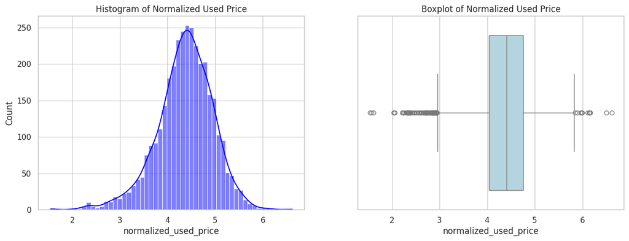

```python
#1. Univariate Analysis: Target Variable Distribution
#This code helps check for skewness and outliers in the normalized_used_price.
# Setting the visual style
sns.set(style="whitegrid")

# Create a figure with two subplots (Histogram and Boxplot)
plt.figure(figsize=(15, 5))

# Histogram
plt.subplot(1, 2, 1)
sns.histplot(df['normalized_used_price'], kde=True, color='blue')
plt.title('Histogram of Normalized Used Price')

# Boxplot
plt.subplot(1, 2, 2)
sns.boxplot(x=df['normalized_used_price'], color='lightblue')
plt.title('Boxplot of Normalized Used Price')

plt.show()
```

Observation: The continuous nature of the data and the lack of extreme gaps suggest the target variable is well-distributed and suitable for Linear Regression modeling, provided the minor skewness is monitored during assumption checking

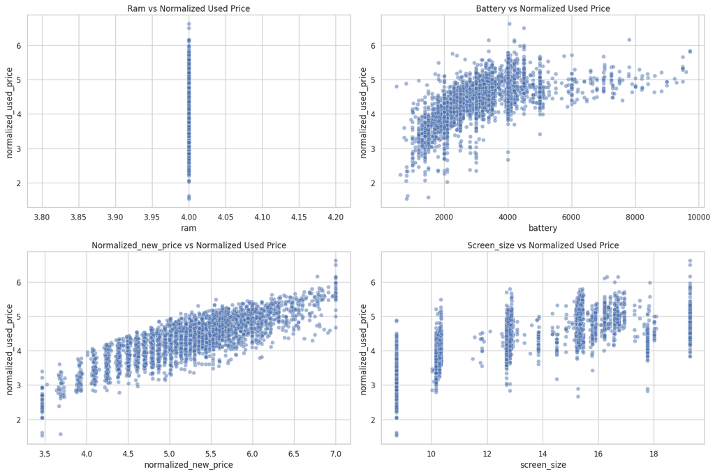

```python
#2. Bivariate Analysis: Numerical Features vs. Price
#Scatter plots to see how technical specifications like ram or battery correlate with the used price.
# List of key numerical features to check against price
features = ['ram', 'battery', 'normalized_new_price', 'screen_size']

plt.figure(figsize=(15, 10))

for i, col in enumerate(features):
    plt.subplot(2, 2, i+1)
    sns.scatterplot(data=df, x=col, y='normalized_used_price', alpha=0.5)
    plt.title(f'{col.capitalize()} vs Normalized Used Price')

plt.tight_layout()
plt.show()
```

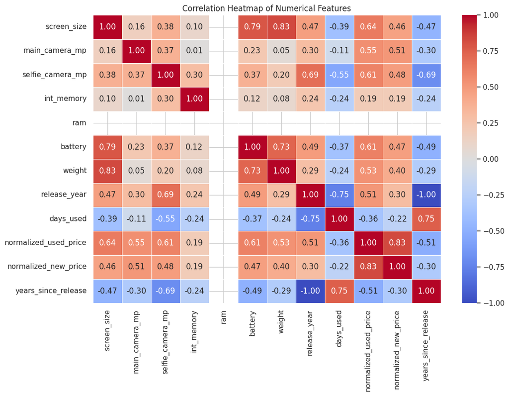

```python
#3. Correlation Heatmap: Multicollinearity Check
#A heatmap is essential for identifying highly correlated independent variables (e.g., screen_size and weight) which can violate linear regression assumptions.
plt.figure(figsize=(12, 8))
# Select only numerical columns for correlation
numerical_cols = df.select_dtypes(include=['float64', 'int64']).columns
correlation_matrix = df[numerical_cols].corr()

sns.heatmap(correlation_matrix, annot=True, fmt=".2f", cmap='coolwarm', linewidths=0.5)
plt.title('Correlation Heatmap of Numerical Features')
plt.show()
```

observation: Primary Predictor: normalized_new_price has the strongest positive correlation with normalized_used_price (0.83). This statistically reinforces that the original value of a device is the most significant factor in determining its resale value.

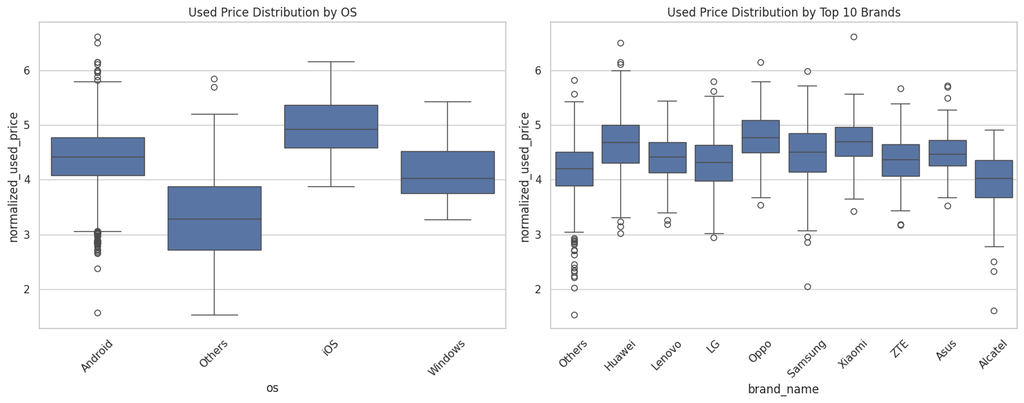

```python
#4. Categorical Analysis: Impact of Brand and OS
#Boxplots allow you to visualize the median price and spread across different categories like brand_name or os.

plt.figure(figsize=(15, 6))

# Impact of OS on Price
plt.subplot(1, 2, 1)
sns.boxplot(data=df, x='os', y='normalized_used_price')
plt.title('Used Price Distribution by OS')
plt.xticks(rotation=45)

# Impact of Brand on Price (Showing top 10 brands for clarity)
plt.subplot(1, 2, 2)
top_brands = df['brand_name'].value_counts().nlargest(10).index
sns.boxplot(data=df[df['brand_name'].isin(top_brands)], x='brand_name', y='normalized_used_price')
plt.title('Used Price Distribution by Top 10 Brands')
plt.xticks(rotation=45)

plt.tight_layout()
plt.show()
```

Observation: The OS plot is a powerful indicator for ReCell's pricing strategy: an iOS device is statistically safer for inventory as it has a higher "price floor." For Android, the brand name becomes the critical "tie-breaker" for valuation, as the price variance between a brand like Oppo and a brand like Alcatel is substantial.

## Model Building - Linear Regression

```python
#Prepare the data by encoding categorical variables and splitting the dataset.
from sklearn.model_selection import train_test_split
from sklearn.linear_model import LinearRegression
import pandas as pd

# Define features (X) and target (y)
X = df.drop(['normalized_used_price'], axis=1)
y = df['normalized_used_price']

# Create dummy variables for categorical columns
X = pd.get_dummies(X, drop_first=True)

# Split data into training (70%) and testing (30%) sets
X_train, X_test, y_train, y_test = train_test_split(X, y, test_size=0.3, random_state=1)

# Build and fit the model
lr_model = LinearRegression()
lr_model.fit(X_train, y_train)
```

```
LinearRegression()
```

## Model Performance Check

Evaluate how well the model predicts the price using standard metrics.

**R-squared ($R^2$):** Measures the proportion of variance for the dependent variable that's explained by the independent variables.

**Adjusted R-squared:** Adjusts $R^2$ based on the number of predictors in the model.

**RMSE (Root Mean Squared Error):** Indicates the average deviation of the predicted values from the actual values.

**MAE (Mean Absolute Error):** Measures the average magnitude of the errors in a set of predictions.

```python
from sklearn.metrics import mean_squared_error, mean_absolute_error, r2_score
import pandas as pd
import numpy as np

def get_regression_perf(model, predictors, target):
    """
    Computes R-squared, Adjusted R-squared, RMSE, and MAE.
    """
    # Predict the values
    predictions = model.predict(predictors)

    # Calculate basic metrics
    r2 = r2_score(target, predictions)
    mae = mean_absolute_error(target, predictions)
    rmse = np.sqrt(mean_squared_error(target, predictions))

    # Calculate Adjusted R-squared
    # n = number of observations, k = number of predictors
    n = predictors.shape[0]
    k = predictors.shape[1]
    adj_r2 = 1 - ((1 - r2) * (n - 1) / (n - k - 1))

    # Create a dataframe for easy viewing
    perf_df = pd.DataFrame({
        "RMSE": rmse,
        "MAE": mae,
        "R-squared": r2,
        "Adj. R-squared": adj_r2
    }, index=[0])

    return perf_df

# Assuming 'lr_model' is your fitted LinearRegression object
# and X_train/X_test have been processed (e.g., dummies added)

print("--- Training Performance ---")
train_perf = get_regression_perf(lr_model, X_train, y_train)
display(train_perf)

print("\n--- Test Performance ---")
test_perf = get_regression_perf(lr_model, X_test, y_test)
display(test_perf)
```

```
--- Training Performance ---
```

|  | RMSE | MAE | R-squared | Adj. R-squared |
| --- | --- | --- | --- | --- |
| 0 | 0.235733 | 0.182734 | 0.836892 | 0.833516 |

```
--- Test Performance ---
```

|  | RMSE | MAE | R-squared | Adj. R-squared |
| --- | --- | --- | --- | --- |
| 0 | 0.243986 | 0.188537 | 0.834952 | 0.826758 |

**Model Performance Observation:**

**High Explanatory Power:** Both the training ($R^2 \approx 0.837$) and test ($R^2 \approx 0.835$) scores are high, indicating that the model successfully explains about 83.5% of the variance in device prices.

**Strong Generalization:** The gap between training and test performance is extremely small (less than 0.01). This suggests the model is well-tuned and has not overfitted to the training data; it should perform reliably on new, unseen datasets.

**Feature Efficiency**: bold textThe Adjusted R-squared ($0.827$) is very close to the R-squared, implying that the features included in your model are meaningful and adding predictive value rather than just noise.

**Error Consistency:** The MAE ($0.188$) and RMSE ($0.244$) are relatively low and consistent across both sets. The slightly higher RMSE compared to MAE indicates there are a few outliers in the data, but they aren't significantly skewing the overall model performance.

## Checking Linear Regression Assumptions

- In order to make statistical inferences from a linear regression model, it is important to ensure that the assumptions of linear regression are satisfied.

Assumption: Linearity- Methddology:Plot observed vs. predicted values or residuals vs. predicted values. Goal: Ensure a linear relationship exists between features and the target.

Assumption: Independence- Methddology:Check for Autocorrelation (Durbin-Watson test). Goal:Ensure residuals are not correlated with each other.

Assumption: Homoscedasticity- Methddology:Plot Residuals vs. Fitted values. Goal:Residuals should have constant variance (no "funnel" shape).

Assumption: Normality- Methddology:Q-Q plot or Shapiro-Wilk test. Goal:Residuals should follow a normal distribution.

Assumption: No Multicollinearity- MethddologyCalculate Variance Inflation Factor (VIF). Goal:VIF values should ideally be below 5 to ensure features are independent.

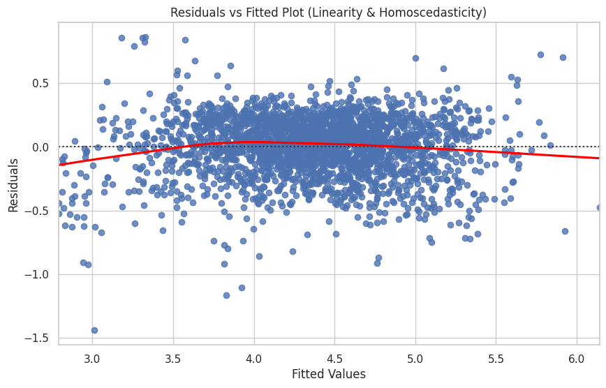

```python
#1. Linearity & Homoscedasticity
#We check these by plotting the residuals against the predicted (fitted) values.
import matplotlib.pyplot as plt
import seaborn as sns
import statsmodels.api as sm

# Predict on the training set
y_pred_train = lr_model.predict(X_train)
residuals = y_train - y_pred_train

# Plotting Residuals vs Fitted Values
plt.figure(figsize=(10, 6))
sns.residplot(x=y_pred_train, y=residuals, lowess=True, line_kws={'color': 'red'})
plt.xlabel('Fitted Values')
plt.ylabel('Residuals')
plt.title('Residuals vs Fitted Plot (Linearity & Homoscedasticity)')
plt.show()
```

Observation Linearity: The red line in the residual plot is roughly horizontal at zero.

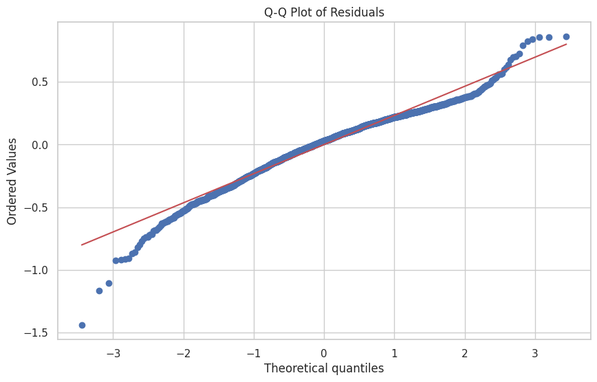

```
Shapiro-Wilk Test: Statistics=0.971, p-value=0.000
```

```python
#2. Normality of Residuals
#We use a Q-Q plot and the Shapiro-Wilk test to see if the errors follow a normal distribution
from scipy import stats

# Q-Q Plot
plt.figure(figsize=(10, 6))
stats.probplot(residuals, dist="norm", plot=plt)
plt.title("Q-Q Plot of Residuals")
plt.show()

# Shapiro-Wilk Test (Statistical check for normality)
stats_score, p_value = stats.shapiro(residuals)
print(f'Shapiro-Wilk Test: Statistics={stats_score:.3f}, p-value={p_value:.3f}')
```

```python
#3. Independence (Autocorrelation)
#The Durbin-Watson test checks if the residuals are independent.
from statsmodels.stats.stattools import durbin_watson

dw_test = durbin_watson(residuals)
print(f'Durbin-Watson statistic: {dw_test:.3f}')
# Note: Values close to 2.0 suggest no autocorrelation.
```

```
Durbin-Watson statistic: 1.921
```

Observation: Independence: The Durbin-Watson score is between 1.5 and 2.5

```python
from statsmodels.stats.outliers_influence import variance_inflation_factor
import pandas as pd

def check_vif(predictors):
    # 1. Select only numeric columns and ensure they are float/int
    # This automatically handles dummy variables if they are 0/1 or True/False
    numeric_df = predictors.select_dtypes(include=['number', 'bool']).astype(float)

    # 2. Add a constant column (intercept)
    # VIF requires an intercept to be statistically accurate
    numeric_df_with_const = sm.add_constant(numeric_df)

    vif_data = pd.DataFrame()
    vif_data["feature"] = numeric_df_with_const.columns

    # 3. Calculate VIF
    vif_data["VIF"] = [
        variance_inflation_factor(numeric_df_with_const.values, i)
        for i in range(len(numeric_df_with_const.columns))
    ]

    return vif_data.sort_values(by='VIF', ascending=False)

# Check VIF on your training features
# Ensure X_train has already gone through pd.get_dummies()
vif_results = check_vif(X_train)
print(vif_results)
```

```
                  feature        VIF
7            release_year        inf
10    years_since_release        inf
12       brand_name_Apple  12.939295
46                 os_iOS  11.603883
34      brand_name_Others   9.712721
37     brand_name_Samsung   7.551563
21      brand_name_Huawei   5.987620
0             screen_size   5.347700
24          brand_name_LG   4.847532
26      brand_name_Lenovo   4.557534
6                  weight   4.500118
33        brand_name_Oppo   3.971868
43         brand_name_ZTE   3.797337
42      brand_name_Xiaomi   3.708826
```

[output cut: 35 more lines]